# Testing the generality of the temperature-size rule in space and time: a case study using intertidal snails

Robin Elahi

August 11, 2016

# Introduction

In this study we used a comparative-historical approach to test the hypothesis that reductions in body size, consistent with climate warming, have occurred over a period of 5–7 decades. Moreover, we examined the consistency of change across a suite of species that span a range of environmental variability. Specifically, we examine changes in the size-frequency distributions of three gastropods inhabiting a gradient of thermal stress in the rocky intertidal between 1947-1963 and 2014-2015.

# Methods

# Predictions

1. Snail size is inversely related to temperature. That is, I expect size declines over time, assuming sea and/or air temperatures have increased during same period [@Barry1995]. Expect opposite pattern if temperatures have decreased, or no pattern if temperatures have not changed.
   1. Prediction: snails are smaller now than 50 years ago
   2. Test: Size ~ Era
2. Change in snail size is mediated by tidal height. Climate warming is expected to be manifested as increases in temperature variability, as well as increases in mean temperature. Temperature variability typically increases with tidal height.
   1. Prediction: An increase in extreme temperatures in the higher intertidal selects for larger individuals because larger snails are less susceptible to dessication mortality [@Gardner2011]
   2. Alternative: Temporal reductions in body size are largest in the high intertidal (e.g., due to metabolic effects without a compensatory increase in consumption)
   3. Test 1: Size ~ Era x Species x Tidal height
   4. Test 2: Temperature ~ Species x Tidal height (tests the assumption that temperature increases with tidal height, and that this response is consistent across species)

# Results (outline)

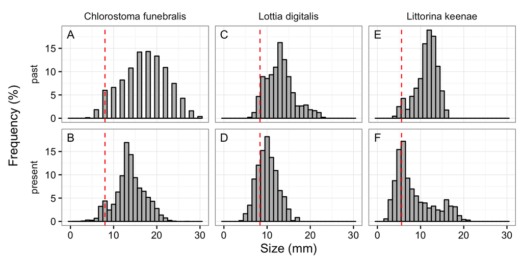

Figure 1. Size frequency distributions of three intertidal snails. The dashed red line indicates the 5th percentile of size for each species in the past. Only snails larger than this threshold were included for all statistical tests and summary calculations. I did this to ensure a conservative test of declining body size; that is, it is possible that the previous investigators sampled the smallest individuals less carefully than we did.

I used linear mixed-effects models (nlme package) to test the hypothesis that snail size frequency distributions differed between era (past vs present), and that this variation was mediated by tidal height.

Table 1. Model selection results for linear mixed effects models testing the fixed effects of era, species, and tidal height on snail body size

| Modnames | K | AIC | Delta_AIC | ModelLik | AICWt | LL | Cum.Wt |
| --- | --- | --- | --- | --- | --- | --- | --- |
| Era x Species x Tidal height | 14 | 40542.24 | 0.000 | 1.000 | 0.976 | -20257.12 | 0.976 |
| All three 2-way intx | 12 | 40549.62 | 7.385 | 0.025 | 0.024 | -20262.81 | 1.000 |
| Era x Tidal height | 6 | 40571.42 | 29.176 | 0.000 | 0.000 | -20279.71 | 1.000 |
| Era x Species | 8 | 40636.81 | 94.572 | 0.000 | 0.000 | -20310.41 | 1.000 |
| Era | 4 | 40779.64 | 237.400 | 0.000 | 0.000 | -20385.82 | 1.000 |
| Species x Tidal height | 8 | 41607.89 | 1065.652 | 0.000 | 0.000 | -20795.95 | 1.000 |
| Species | 5 | 41621.05 | 1078.808 | 0.000 | 0.000 | -20805.52 | 1.000 |
| Null model | 3 | 41627.09 | 1084.847 | 0.000 | 0.000 | -20810.54 | 1.000 |
| Tidal height | 4 | 41629.06 | 1086.817 | 0.000 | 0.000 | -20810.53 | 1.000 |

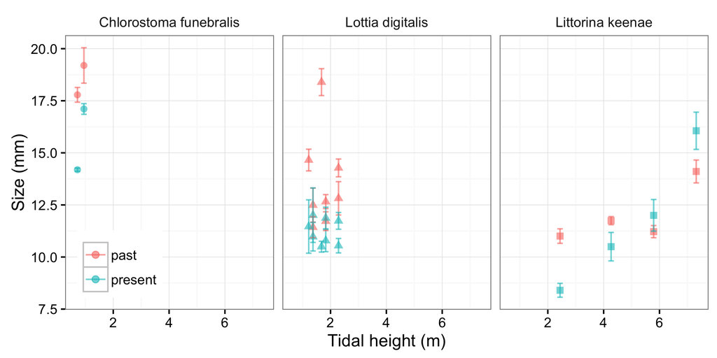

Figure 2. Snail body size (mean +- CI) as a function of tidal height and species. In general, mean body size has declined. However, Littorina keenae has actually increased in mean body size in the high intertidal.

The temporal increase in size for Littorina keenae was consistent with the prediction that extreme temperatures select for larger snails. Notably, all of the snails at the highest intertidal location were concentrated in a single crevice, suggesting that abiotic conditions (e.g., temperature, wind, dessication risk) were considerably more stressful in this zone (zone D).

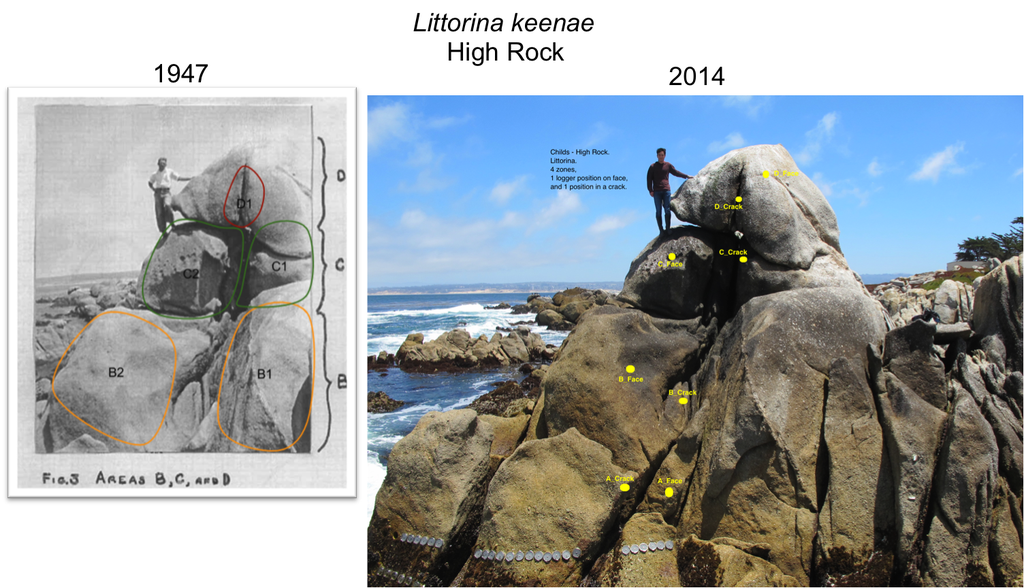

Figure 3. Comparison of the sampling areas (A-D) for Littorina keenae, on High Rock, at Cabrillo Point in Pacific Grove, California. In the 1947 photo, the colored lines represent areas that were resampled in 2014 within three of the four original zones sampled by Childs (A-D). In the 2014 photo, the yellow points indicate the locations of temperature loggers. The sampling areas span approximately 6m (2-8m above MLLW)

To test the assumption that temperature means and variability increased with tidal height, we deployed temperature loggers in locations that spanned the tidal range of each sampling area. For Littorina keenae, we placed a logger each in a crevice and the exposed face for each sampling area (A-D).

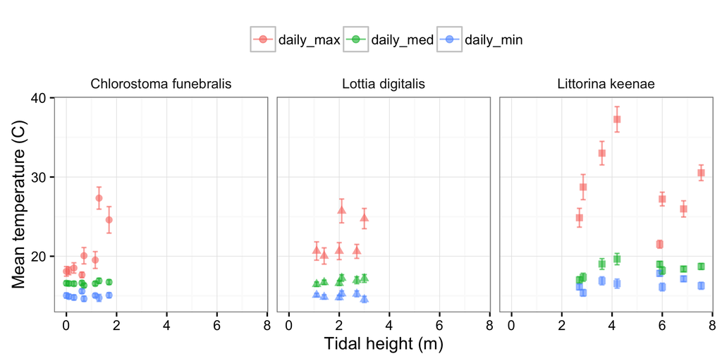

Figure 4. Habitat temperatures (mean +- CI of daily maximum, median, and minimum) as a function of tidal height and species.

In general, habitat temperature increased with tidal height, except for the two highest zones for Littorina keenae. We hypothesize that these higher zones displayed lower than expected temperatures because:

1. The lower projected area results in lower radiative heating of the rock
2. The white projected area, due to bird guano, results in reflection of solar radiation
3. The high elevation, relative to the surrounding intertidal habitat, facilitates cooling through evaporation due to boundary layer effects

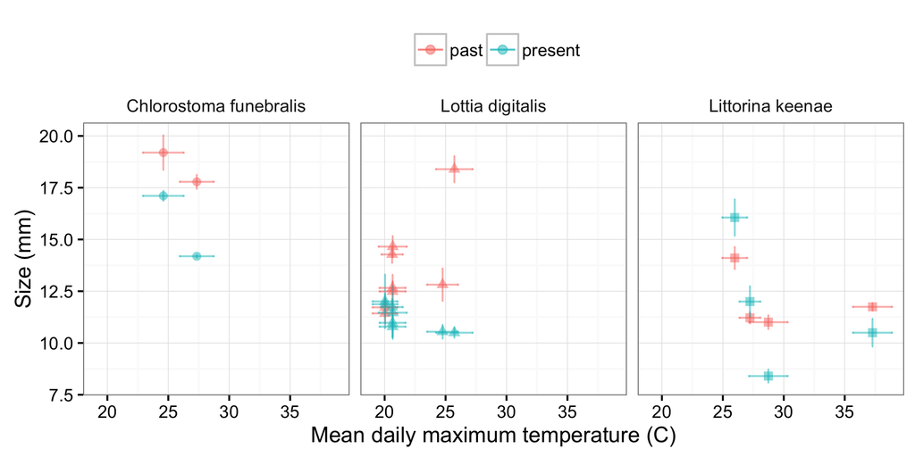

Figure 5. Body size (mean +- CI) plotted as a function of maximum habitat temperature (mean +- CI of daily maximum) as a function of era and tidal height for all three species

This figure supports the hypothesis that maximum temperature mediated the direction of size change in Littorina keenae. That is, up to a mean maximum temperature of 28C, snails increased in size. Beyond this threshold, snails decreased in size. Across all three species, the reductions in body size tended to be largest in the sampling areas that exhibited the highest maximum habitat temperatures.